# Data Cleaning - Covid Data

Kazmer Nagy-Betegh

2021-11-18

[Covid Data variables explanation](https://github.com/owid/covid-19-data/tree/master/public/data)

```r
library(tidyverse)
library(vroom)
library(here)
library(rmarkdown)
library(zoo)
# to get the data as of Nov 14, 2021, just read the csv saved in the data folder
# covid_data <- vroom(here::here("data", "covid_data.csv"))

# if you want to get an up-to-date version, run the following lines
url <- "https://covid.ourworldindata.org/data/owid-covid-data.csv"
covid_data <- vroom(url) %>%
  mutate(perc = round(100 * people_fully_vaccinated / population, 2))
glimpse(covid_data)
```

```
## Rows: 134,020
## Columns: 68
## $ iso_code                                   <chr> "AFG", "AFG", "AFG", "AFG",…
## $ continent                                  <chr> "Asia", "Asia", "Asia", "As…
## $ location                                   <chr> "Afghanistan", "Afghanistan…
## $ date                                       <date> 2020-02-24, 2020-02-25, 20…
## $ total_cases                                <dbl> 5, 5, 5, 5, 5, 5, 5, 5, 5, …
## $ new_cases                                  <dbl> 5, 0, 0, 0, 0, 0, 0, 0, 0, …
## $ new_cases_smoothed                         <dbl> NA, NA, NA, NA, NA, 0.714, …
## $ total_deaths                               <dbl> NA, NA, NA, NA, NA, NA, NA,…
## $ new_deaths                                 <dbl> NA, NA, NA, NA, NA, NA, NA,…
## $ new_deaths_smoothed                        <dbl> NA, NA, NA, NA, NA, 0, 0, 0…
## $ total_cases_per_million                    <dbl> 0.126, 0.126, 0.126, 0.126,…
## $ new_cases_per_million                      <dbl> 0.126, 0.000, 0.000, 0.000,…
## $ new_cases_smoothed_per_million             <dbl> NA, NA, NA, NA, NA, 0.018, …
```

[output cut: 55 more lines]

```r
skimr::skim(covid_data)
```

Data summary

| Name | covid_data |
| --- | --- |
| Number of rows | 134020 |
| Number of columns | 68 |
| _______________________ |  |
| Column type frequency: |  |
| character | 4 |
| Date | 1 |
| numeric | 63 |
| ________________________ |  |
| Group variables | None |

**Variable type: character**

| skim_variable | n_missing | complete_rate | min | max | empty | n_unique | whitespace |
| --- | --- | --- | --- | --- | --- | --- | --- |
| iso_code | 0 | 1.00 | 3 | 8 | 0 | 237 | 0 |
| continent | 8552 | 0.94 | 4 | 13 | 0 | 6 | 0 |
| location | 0 | 1.00 | 4 | 32 | 0 | 237 | 0 |
| tests_units | 63896 | 0.52 | 13 | 15 | 0 | 4 | 0 |

**Variable type: Date**

| skim_variable | n_missing | complete_rate | min | max | median | n_unique |
| --- | --- | --- | --- | --- | --- | --- |
| date | 0 | 1 | 2020-01-01 | 2021-11-17 | 2021-01-27 | 687 |

**Variable type: numeric**

| skim_variable | n_missing | complete_rate | mean | sd | p0 | p25 | p50 | p75 | p100 | hist |
| --- | --- | --- | --- | --- | --- | --- | --- | --- | --- | --- |
| total_cases | 7368 | 0.95 | 2073588.00 | 11821222.61 | 1.00 | 2433.00 | 27878.50 | 269184.50 | 2.554584e+08 | ▇▁▁▁▁ |
| new_cases | 7370 | 0.95 | 8394.76 | 43719.57 | -74347.00 | 3.00 | 105.00 | 1086.00 | 9.082900e+05 | ▇▁▁▁▁ |
| new_cases_smoothed | 8413 | 0.94 | 8409.26 | 43182.99 | -6223.00 | 10.43 | 130.86 | 1140.79 | 8.272197e+05 | ▇▁▁▁▁ |
| total_deaths | 18533 | 0.86 | 51034.79 | 261802.57 | 1.00 | 82.00 | 756.00 | 6565.00 | 5.124002e+06 | ▇▁▁▁▁ |
| new_deaths | 18337 | 0.86 | 183.71 | 870.04 | -1918.00 | 0.00 | 2.00 | 22.00 | 1.800700e+04 | ▇▁▁▁▁ |
| new_deaths_smoothed | 8413 | 0.94 | 168.44 | 816.45 | -232.14 | 0.14 | 2.00 | 18.57 | 1.470329e+04 | ▇▁▁▁▁ |
| total_cases_per_million | 8018 | 0.94 | 20127.52 | 33409.59 | 0.00 | 419.08 | 3247.86 | 25385.59 | 2.441426e+05 | ▇▁▁▁▁ |
| new_cases_per_million | 8020 | 0.94 | 87.69 | 202.74 | -3125.83 | 0.33 | 11.35 | 83.99 | 8.620690e+03 | ▁▇▁▁▁ |
| new_cases_smoothed_per_million | 9058 | 0.93 | 87.56 | 171.94 | -272.97 | 1.66 | 15.97 | 93.50 | 3.385470e+03 | ▇▁▁▁▁ |
| total_deaths_per_million | 19170 | 0.86 | 408.17 | 668.97 | 0.00 | 12.24 | 81.89 | 534.58 | 6.017520e+03 | ▇▁▁▁▁ |
| new_deaths_per_million | 18974 | 0.86 | 1.59 | 4.12 | -75.91 | 0.00 | 0.17 | 1.38 | 2.035100e+02 | ▁▇▁▁▁ |
| new_deaths_smoothed_per_million | 9058 | 0.93 | 1.45 | 3.10 | -10.84 | 0.00 | 0.21 | 1.40 | 9.480000e+01 | ▇▁▁▁▁ |
| reproduction_rate | 29039 | 0.78 | 1.00 | 0.34 | -0.03 | 0.83 | 1.01 | 1.17 | 6.000000e+00 | ▇▂▁▁▁ |
| icu_patients | 117885 | 0.12 | 892.33 | 2804.30 | 0.00 | 25.00 | 128.00 | 534.00 | 2.889100e+04 | ▇▁▁▁▁ |
| icu_patients_per_million | 117885 | 0.12 | 22.23 | 24.45 | 0.00 | 3.92 | 13.16 | 33.68 | 1.926400e+02 | ▇▂▁▁▁ |
| hosp_patients | 115109 | 0.14 | 4001.93 | 11129.05 | 0.00 | 107.00 | 536.00 | 2453.00 | 1.332680e+05 | ▇▁▁▁▁ |
| hosp_patients_per_million | 115109 | 0.14 | 156.20 | 210.77 | 0.00 | 22.63 | 70.56 | 202.14 | 1.544080e+03 | ▇▁▁▁▁ |
| weekly_icu_admissions | 132664 | 0.01 | 228.46 | 498.02 | 0.00 | 6.02 | 29.11 | 177.36 | 4.002460e+03 | ▇▁▁▁▁ |
| weekly_icu_admissions_per_million | 132664 | 0.01 | 16.50 | 31.72 | 0.00 | 1.53 | 5.54 | 16.91 | 2.795000e+02 | ▇▁▁▁▁ |
| weekly_hosp_admissions | 131867 | 0.02 | 3077.72 | 10443.95 | 0.00 | 44.04 | 263.26 | 1309.00 | 1.162430e+05 | ▇▁▁▁▁ |
| weekly_hosp_admissions_per_million | 131867 | 0.02 | 84.88 | 138.97 | 0.00 | 10.98 | 36.94 | 107.07 | 1.365540e+03 | ▇▁▁▁▁ |
| new_tests | 78102 | 0.42 | 57784.73 | 197749.18 | 1.00 | 2139.25 | 7884.00 | 30603.00 | 3.740296e+06 | ▇▁▁▁▁ |
| total_tests | 77761 | 0.42 | 12296390.04 | 50404097.63 | 0.00 | 263917.00 | 1332203.00 | 5538824.00 | 6.426871e+08 | ▇▁▁▁▁ |
| total_tests_per_thousand | 77761 | 0.42 | 517.02 | 1263.72 | 0.00 | 23.01 | 118.02 | 470.01 | 1.744858e+04 | ▇▁▁▁▁ |
| new_tests_per_thousand | 78102 | 0.42 | 2.55 | 6.69 | 0.00 | 0.19 | 0.75 | 2.35 | 3.257600e+02 | ▇▁▁▁▁ |
| new_tests_smoothed | 65923 | 0.51 | 53880.09 | 175992.82 | 0.00 | 2292.00 | 8448.00 | 33080.00 | 3.080396e+06 | ▇▁▁▁▁ |
| new_tests_smoothed_per_thousand | 65923 | 0.51 | 2.43 | 5.73 | 0.00 | 0.21 | 0.83 | 2.42 | 9.004000e+01 | ▇▁▁▁▁ |
| positive_rate | 70438 | 0.47 | 0.09 | 0.10 | 0.00 | 0.02 | 0.05 | 0.12 | 1.000000e+00 | ▇▁▁▁▁ |
| tests_per_case | 71099 | 0.47 | 160.65 | 849.35 | 1.00 | 8.00 | 19.50 | 58.00 | 5.000000e+04 | ▇▁▁▁▁ |
| total_vaccinations | 99984 | 0.25 | 110734741.16 | 519006965.33 | 0.00 | 374799.25 | 2820200.00 | 16890643.00 | 7.594846e+09 | ▇▁▁▁▁ |
| people_vaccinated | 101568 | 0.24 | 60174713.13 | 286803686.43 | 0.00 | 271713.50 | 1910431.50 | 10663933.75 | 4.127343e+09 | ▇▁▁▁▁ |
| people_fully_vaccinated | 104542 | 0.22 | 41720284.83 | 210968807.38 | 1.00 | 159111.50 | 1273664.00 | 7554581.25 | 3.246584e+09 | ▇▁▁▁▁ |
| total_boosters | 127839 | 0.05 | 3455368.45 | 11703810.67 | 1.00 | 212.00 | 67272.00 | 1564986.00 | 1.764699e+08 | ▇▁▁▁▁ |
| new_vaccinations | 105702 | 0.21 | 1057049.35 | 4092032.50 | 0.00 | 6146.00 | 37599.00 | 240976.50 | 5.634403e+07 | ▇▁▁▁▁ |
| new_vaccinations_smoothed | 73362 | 0.45 | 505392.23 | 2776526.38 | 0.00 | 1043.00 | 8392.00 | 61254.75 | 4.323352e+07 | ▇▁▁▁▁ |
| total_vaccinations_per_hundred | 99984 | 0.25 | 52.18 | 50.70 | 0.00 | 6.50 | 35.52 | 90.06 | 2.804000e+02 | ▇▃▂▁▁ |
| people_vaccinated_per_hundred | 101568 | 0.24 | 30.07 | 26.27 | 0.00 | 4.78 | 23.99 | 53.30 | 1.210600e+02 | ▇▃▃▁▁ |
| people_fully_vaccinated_per_hundred | 104542 | 0.22 | 23.76 | 24.03 | 0.00 | 2.68 | 14.59 | 41.89 | 1.181800e+02 | ▇▂▂▁▁ |
| total_boosters_per_hundred | 127839 | 0.05 | 3.01 | 6.99 | 0.00 | 0.00 | 0.11 | 2.35 | 4.341000e+01 | ▇▁▁▁▁ |
| new_vaccinations_smoothed_per_million | 73362 | 0.45 | 3404.93 | 4117.11 | 0.00 | 599.00 | 2196.00 | 4929.00 | 1.174970e+05 | ▇▁▁▁▁ |
| new_people_vaccinated_smoothed | 74658 | 0.44 | 270802.92 | 2508260.06 | 0.00 | 547.00 | 4539.00 | 32146.00 | 1.006320e+08 | ▇▁▁▁▁ |
| new_people_vaccinated_smoothed_per_hundred | 74658 | 0.44 | 0.18 | 0.28 | 0.00 | 0.03 | 0.10 | 0.24 | 1.175000e+01 | ▇▁▁▁▁ |
| stringency_index | 24692 | 0.82 | 56.21 | 20.66 | 0.00 | 42.59 | 56.94 | 72.22 | 1.000000e+02 | ▁▅▇▇▃ |
| population | 953 | 0.99 | 157327029.73 | 728171766.44 | 47.00 | 2078723.00 | 9749625.00 | 37344787.00 | 7.874966e+09 | ▇▁▁▁▁ |
| population_density | 12732 | 0.90 | 398.80 | 1859.39 | 0.14 | 36.25 | 83.48 | 209.59 | 2.054677e+04 | ▇▁▁▁▁ |
| median_age | 18452 | 0.86 | 30.50 | 9.12 | 15.10 | 22.20 | 29.70 | 39.10 | 4.820000e+01 | ▇▆▇▆▆ |
| aged_65_older | 19730 | 0.85 | 8.74 | 6.18 | 1.14 | 3.47 | 6.38 | 14.18 | 2.705000e+01 | ▇▃▂▂▁ |
| aged_70_older | 19083 | 0.86 | 5.53 | 4.22 | 0.53 | 2.06 | 3.87 | 8.68 | 1.849000e+01 | ▇▃▂▂▁ |
| gdp_per_capita | 17704 | 0.87 | 19226.14 | 20056.73 | 661.24 | 4449.90 | 12895.64 | 27216.44 | 1.169356e+05 | ▇▂▁▁▁ |
| extreme_poverty | 56249 | 0.58 | 13.51 | 19.99 | 0.10 | 0.60 | 2.20 | 21.20 | 7.760000e+01 | ▇▁▁▁▁ |
| cardiovasc_death_rate | 18229 | 0.86 | 260.03 | 119.86 | 79.37 | 168.71 | 243.81 | 329.94 | 7.244200e+02 | ▇▇▃▁▁ |
| diabetes_prevalence | 14406 | 0.89 | 8.04 | 4.31 | 0.99 | 5.31 | 7.11 | 10.08 | 3.053000e+01 | ▇▇▂▁▁ |
| female_smokers | 43815 | 0.67 | 10.59 | 10.50 | 0.10 | 1.90 | 6.30 | 19.30 | 4.400000e+01 | ▇▂▂▁▁ |
| male_smokers | 45119 | 0.66 | 32.75 | 13.51 | 7.70 | 21.60 | 31.40 | 41.30 | 7.810000e+01 | ▆▇▆▂▁ |
| handwashing_facilities | 75737 | 0.43 | 50.86 | 31.82 | 1.19 | 20.86 | 49.84 | 83.24 | 1.000000e+02 | ▇▅▅▅▇ |
| hospital_beds_per_thousand | 28792 | 0.79 | 3.03 | 2.46 | 0.10 | 1.30 | 2.40 | 4.00 | 1.380000e+01 | ▇▃▂▁▁ |
| life_expectancy | 9426 | 0.93 | 73.26 | 7.53 | 53.28 | 67.92 | 74.62 | 78.74 | 8.675000e+01 | ▁▃▅▇▅ |
| human_development_index | 18115 | 0.86 | 0.73 | 0.15 | 0.39 | 0.60 | 0.74 | 0.84 | 9.600000e-01 | ▂▅▅▇▇ |
| excess_mortality_cumulative_absolute | 129297 | 0.04 | 32100.16 | 90757.48 | -31959.40 | -162.70 | 2361.90 | 20258.25 | 8.708303e+05 | ▇▁▁▁▁ |
| excess_mortality_cumulative | 129297 | 0.04 | 8.72 | 15.97 | -27.35 | -0.95 | 5.25 | 13.57 | 1.068400e+02 | ▃▇▁▁▁ |
| excess_mortality | 129297 | 0.04 | 15.96 | 31.01 | -95.92 | -0.80 | 6.63 | 22.42 | 3.736100e+02 | ▂▇▁▁▁ |
| excess_mortality_cumulative_per_million | 129297 | 0.04 | 787.61 | 1170.92 | -1728.84 | -41.66 | 364.41 | 1368.22 | 6.170370e+03 | ▂▇▂▁▁ |
| perc | 104563 | 0.22 | 23.77 | 24.04 | 0.00 | 2.67 | 14.61 | 41.90 | 1.181800e+02 | ▇▂▂▁▁ |

```r
original <- covid_data

covid_data <- covid_data%>%
  mutate(date = as.Date(date))

covid_data %>%
  count(tests_units, sort = TRUE)
```

```
## # A tibble: 5 × 2
##   tests_units         n
##   <chr>           <int>
## 1 <NA>            63896
## 2 tests performed 44258
## 3 people tested   13099
## 4 samples tested  11495
## 5 units unclear    1272
```

```r
covid_data %>%
  filter(!is.na(tests_units)) %>%
  arrange(total_tests) %>%
  select(iso_code, total_cases, date, tests_units, total_tests)
```

```
## # A tibble: 70,124 × 5
##    iso_code total_cases date       tests_units     total_tests
##    <chr>          <dbl> <date>     <chr>                 <dbl>
##  1 CAN                4 2020-01-31 tests performed           0
##  2 DNK               NA 2020-02-02 tests performed           1
##  3 EST               NA 2020-02-05 tests performed           1
##  4 ETH                1 2020-03-13 tests performed           1
##  5 GTM               NA 2020-02-17 people tested             1
##  6 PRY               NA 2020-03-07 tests performed           1
##  7 SEN               NA 2020-02-28 tests performed           1
##  8 LKA                1 2020-02-18 tests performed           1
##  9 CRI                1 2020-03-06 people tested             2
## 10 DNK               NA 2020-02-13 tests performed           2
## # … with 70,114 more rows
```

The tests_units are going to be grouped the following way: *tests performed, people tested, samples tested* will be considered together as it is unlikely that a significant amount of people got tested more than once a day. *NA* and *units unclear* makes the testing data input unusable. *NA* likely indicates when testing has not begun yet at that date within the country.

```r
covid_data <- covid_data %>%
  mutate(tests_units_grouped = case_when(tests_units == "tests performed" ~ "tested",
                                 tests_units == "people tested"~ "tested",
                                 tests_units == "samples tested"~ "tested",
                                 tests_units == NA ~ "testing not started",
                                 TRUE ~ tests_units))
```

Saving the date the first case is recorded within each country

```r
covid_data <- covid_data %>%
  group_by(iso_code) %>%
  arrange(date) %>%
  filter(total_cases >= 0) %>%
  mutate(start_date = date[1]) %>%
  ungroup()
```

Counting the days since the first recoded case

```r
covid_data <- covid_data %>%
  group_by(iso_code) %>%
  mutate(pandemic_days = as.numeric(date - start_date , units = "days")) %>%
  arrange(date) %>%
  ungroup()
```

total number of hospitalisations

```r
covid_data <- covid_data %>%
  group_by(date, iso_code) %>%
  mutate(total_hosp = cumsum(hosp_patients),
         .after = hosp_patients)

glimpse(covid_data)
```

```
## Rows: 126,652
## Columns: 72
## Groups: date, iso_code [126,652]
## $ iso_code                                   <chr> "OWID_ASI", "CHN", "OWID_HI…
## $ continent                                  <chr> NA, "Asia", NA, "Asia", NA,…
## $ location                                   <chr> "Asia", "China", "High inco…
## $ date                                       <date> 2020-01-22, 2020-01-22, 20…
## $ total_cases                                <dbl> 556, 548, 5, 2, 1, 1, 1, 4,…
## $ new_cases                                  <dbl> 0, NA, 0, NA, 0, NA, NA, NA…
## $ new_cases_smoothed                         <dbl> NA, NA, NA, NA, NA, NA, NA,…
## $ total_deaths                               <dbl> 17, 17, NA, NA, NA, NA, NA,…
## $ new_deaths                                 <dbl> 0, NA, 0, NA, 0, NA, NA, NA…
## $ new_deaths_smoothed                        <dbl> NA, NA, NA, NA, NA, NA, NA,…
## $ total_cases_per_million                    <dbl> 0.119, 0.379, 0.004, 0.016,…
## $ new_cases_per_million                      <dbl> 0.000, NA, 0.000, NA, 0.000…
```

[output cut: 60 more lines]

Tonga is either missing data or covid really only has showed up there 2021 October. Quick search confirms this is a correct datapoint [BBC news Tonga First Case](https://www.bbc.co.uk/news/world-asia-59101584)

```r
covid_data %>%
  filter(start_date == "2021-10-29")
```

```
## # A tibble: 20 × 72
## # Groups:   date, iso_code [20]
##    iso_code continent location date       total_cases new_cases new_cases_smoot…
##    <chr>    <chr>     <chr>    <date>           <dbl>     <dbl>            <dbl>
##  1 TON      Oceania   Tonga    2021-10-29           1         1           NA
##  2 TON      Oceania   Tonga    2021-10-30           1         0           NA
##  3 TON      Oceania   Tonga    2021-10-31           1         0           NA
##  4 TON      Oceania   Tonga    2021-11-01           1         0           NA
##  5 TON      Oceania   Tonga    2021-11-02           1         0           NA
##  6 TON      Oceania   Tonga    2021-11-03           1         0            0.143
##  7 TON      Oceania   Tonga    2021-11-04           1         0            0.143
##  8 TON      Oceania   Tonga    2021-11-05           1         0            0
##  9 TON      Oceania   Tonga    2021-11-06           1         0            0
## 10 TON      Oceania   Tonga    2021-11-07           1         0            0
## 11 TON      Oceania   Tonga    2021-11-08           1         0            0
## 12 TON      Oceania   Tonga    2021-11-09           1         0            0
## 13 TON      Oceania   Tonga    2021-11-10           1         0            0
## 14 TON      Oceania   Tonga    2021-11-11           1         0            0
## 15 TON      Oceania   Tonga    2021-11-12           1         0            0
## 16 TON      Oceania   Tonga    2021-11-13           1         0            0
## 17 TON      Oceania   Tonga    2021-11-14           1         0            0
## 18 TON      Oceania   Tonga    2021-11-15           1         0            0
## 19 TON      Oceania   Tonga    2021-11-16           1         0            0
## 20 TON      Oceania   Tonga    2021-11-17           1         0            0
## # … with 65 more variables: total_deaths <dbl>, new_deaths <dbl>,
## #   new_deaths_smoothed <dbl>, total_cases_per_million <dbl>,
## #   new_cases_per_million <dbl>, new_cases_smoothed_per_million <dbl>,
## #   total_deaths_per_million <dbl>, new_deaths_per_million <dbl>,
## #   new_deaths_smoothed_per_million <dbl>, reproduction_rate <dbl>,
## #   icu_patients <dbl>, icu_patients_per_million <dbl>, hosp_patients <dbl>,
## #   total_hosp <dbl>, hosp_patients_per_million <dbl>, …
```

checking relationship between total_cases and new_cases There are instances of new_cases which are negative. This I assume is incorrect, but it reduces the total number of cases as total_cases seems to follow a cumullative sum relationship with new cases.

```r
covid_data %>%
  arrange((new_cases_smoothed))
```

```
## # A tibble: 126,652 × 72
## # Groups:   date, iso_code [126,652]
##    iso_code continent location date       total_cases new_cases new_cases_smoot…
##    <chr>    <chr>     <chr>    <date>           <dbl>     <dbl>            <dbl>
##  1 ESP      Europe    Spain    2021-03-08     3160970     11958           -6223
##  2 ESP      Europe    Spain    2021-03-05     3149012      6654           -5649.
##  3 ESP      Europe    Spain    2021-03-06     3149012         0           -5649.
##  4 ESP      Europe    Spain    2021-03-07     3149012         0           -5649.
##  5 ESP      Europe    Spain    2021-03-04     3142358      6037           -5408.
##  6 ESP      Europe    Spain    2021-03-03     3136321      6137           -4903.
##  7 ESP      Europe    Spain    2021-03-02     3130184    -74347           -4464
##  8 KAZ      Asia      Kazakhs… 2021-07-30      633469      8304           -1131.
##  9 FRA      Europe    France   2020-04-10       56600      1566           -1122.
## 10 FRA      Europe    France   2020-04-08       51250      3855            -839.
## # … with 126,642 more rows, and 65 more variables: total_deaths <dbl>,
## #   new_deaths <dbl>, new_deaths_smoothed <dbl>, total_cases_per_million <dbl>,
## #   new_cases_per_million <dbl>, new_cases_smoothed_per_million <dbl>,
## #   total_deaths_per_million <dbl>, new_deaths_per_million <dbl>,
## #   new_deaths_smoothed_per_million <dbl>, reproduction_rate <dbl>,
## #   icu_patients <dbl>, icu_patients_per_million <dbl>, hosp_patients <dbl>,
## #   total_hosp <dbl>, hosp_patients_per_million <dbl>, …
```

```r
covid_data %>%
  arrange(new_cases)
```

```
## # A tibble: 126,652 × 72
## # Groups:   date, iso_code [126,652]
##    iso_code continent location date       total_cases new_cases new_cases_smoot…
##    <chr>    <chr>     <chr>    <date>           <dbl>     <dbl>            <dbl>
##  1 ESP      Europe    Spain    2021-03-02     3130184    -74347           -4464
##  2 KAZ      Asia      Kazakhs… 2021-07-24      582013    -59375            4947.
##  3 FRA      Europe    France   2020-11-04     1593146    -46121           44280.
##  4 FRA      Europe    France   2020-04-04       47376    -17076            1383.
##  5 ESP      Europe    Spain    2020-04-24      202990    -10034            1736.
##  6 ECU      South Am… Ecuador  2020-09-07      110092     -7953            -525
##  7 GBR      Europe    United … 2021-04-09     4380167     -4787            1743.
##  8 FRA      Europe    France   2020-04-07       47395     -3489            -698
##  9 FRA      Europe    France   2020-06-03      187509     -3226             357.
## 10 GBR      Europe    United … 2021-05-18     4466220     -2362            1539.
## # … with 126,642 more rows, and 65 more variables: total_deaths <dbl>,
## #   new_deaths <dbl>, new_deaths_smoothed <dbl>, total_cases_per_million <dbl>,
## #   new_cases_per_million <dbl>, new_cases_smoothed_per_million <dbl>,
## #   total_deaths_per_million <dbl>, new_deaths_per_million <dbl>,
## #   new_deaths_smoothed_per_million <dbl>, reproduction_rate <dbl>,
## #   icu_patients <dbl>, icu_patients_per_million <dbl>, hosp_patients <dbl>,
## #   total_hosp <dbl>, hosp_patients_per_million <dbl>, …
```

```r
covid_data %>%
  filter(location == "Spain",
         date >= "2021-03-01") %>%
  select(iso_code, location, date, total_cases, new_cases, new_cases_smoothed, tests_per_case, tests_units, positive_rate, new_tests_smoothed)
```

```
## # A tibble: 262 × 10
## # Groups:   date, iso_code [262]
##    iso_code location date       total_cases new_cases new_cases_smoothed
##    <chr>    <chr>    <date>           <dbl>     <dbl>              <dbl>
##  1 ESP      Spain    2021-03-01     3204531     15978              7223.
##  2 ESP      Spain    2021-03-02     3130184    -74347             -4464
##  3 ESP      Spain    2021-03-03     3136321      6137             -4903.
##  4 ESP      Spain    2021-03-04     3142358      6037             -5408.
##  5 ESP      Spain    2021-03-05     3149012      6654             -5649.
##  6 ESP      Spain    2021-03-06     3149012         0             -5649.
##  7 ESP      Spain    2021-03-07     3149012         0             -5649.
##  8 ESP      Spain    2021-03-08     3160970     11958             -6223
##  9 ESP      Spain    2021-03-09     3164982      4012              4971.
## 10 ESP      Spain    2021-03-10     3172101      7119              5111.
## # … with 252 more rows, and 4 more variables: tests_per_case <dbl>,
## #   tests_units <chr>, positive_rate <dbl>, new_tests_smoothed <dbl>
```

```r
covid_data %>%
  filter(new_cases <0)
```

```
## # A tibble: 81 × 72
## # Groups:   date, iso_code [81]
##    iso_code continent location date       total_cases new_cases new_cases_smoot…
##    <chr>    <chr>     <chr>    <date>           <dbl>     <dbl>            <dbl>
##  1 ISR      Asia      Israel   2020-03-11          60       -28            6.43
##  2 AFG      Asia      Afghani… 2020-03-20          24        -2            1.86
##  3 LBR      Africa    Liberia  2020-03-21           3        -3           NA
##  4 SYC      Africa    Seychel… 2020-03-21           7        -3            1
##  5 GUY      South Am… Guyana   2020-03-24           5       -15           -0.286
##  6 FRA      Europe    France   2020-04-04       47376    -17076         1383.
##  7 FRA      Europe    France   2020-04-07       47395     -3489         -698
##  8 URY      South Am… Uruguay  2020-04-12         480       -21           10.6
##  9 UGA      Africa    Uganda   2020-04-18          55        -1            0.286
## 10 FRA      Europe    France   2020-04-23      157158     -1709         1713.
## # … with 71 more rows, and 65 more variables: total_deaths <dbl>,
## #   new_deaths <dbl>, new_deaths_smoothed <dbl>, total_cases_per_million <dbl>,
## #   new_cases_per_million <dbl>, new_cases_smoothed_per_million <dbl>,
## #   total_deaths_per_million <dbl>, new_deaths_per_million <dbl>,
## #   new_deaths_smoothed_per_million <dbl>, reproduction_rate <dbl>,
## #   icu_patients <dbl>, icu_patients_per_million <dbl>, hosp_patients <dbl>,
## #   total_hosp <dbl>, hosp_patients_per_million <dbl>, …
```

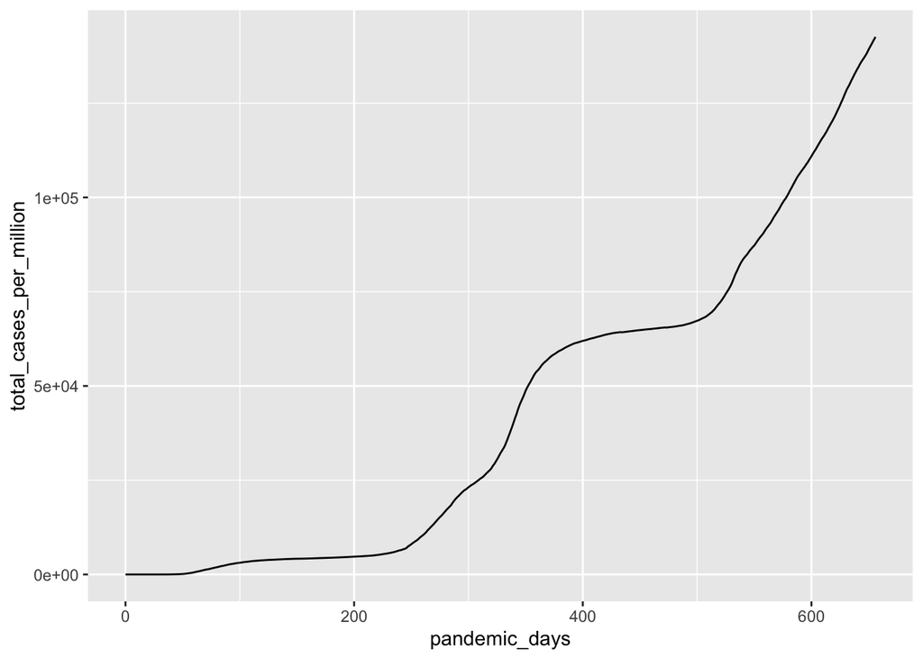

```r
covid_data %>%
  filter(location == "United Kingdom") %>%
  ggplot()+
  geom_line(aes(x = pandemic_days,
                y = total_cases_per_million))
```

I’ll recalculate all the variables that depend on *new_cases* as I will remove any negative variable from new cases.

```r
covid_data <- covid_data %>%
  mutate(new_cases = ifelse(new_cases >= 0, new_cases, 0))


# need to calcualte the assumed population of each location in millions

covid_data <- covid_data %>%
  group_by(iso_code) %>%
  mutate(population = max(total_cases)/max(total_cases_per_million))%>%
  ungroup()


covid_data <- covid_data %>%
  group_by(iso_code) %>%
  mutate(total_cases = cumsum(new_cases)) %>%
  mutate(new_cases_smoothed = rollsumr(new_cases, k = 7, fill = NA)) %>%
  mutate(total_cases_per_million = total_cases/population) %>%
  mutate(new_cases_per_million = new_cases/population) %>%
  mutate(new_cases_smoothed_per_million = rollsumr(new_cases_per_million, k = 7, fill = NA)) %>%
  ungroup()
```

Repeat the same process for deaths

```r
covid_data <- covid_data %>%
  mutate(new_deaths = ifelse(new_deaths >= 0, new_cases, 0))


covid_data <- covid_data %>%
  group_by(iso_code) %>%
  mutate(total_deaths = cumsum(total_deaths)) %>%
  mutate(new_deaths_smoothed = rollsumr(new_deaths, k = 7, fill = NA)) %>%
  mutate(total_deaths_per_million = total_deaths/population) %>%
  mutate(new_deaths_per_million = new_deaths/population) %>%
  mutate(new_deaths_smoothed_per_million = rollsumr(new_deaths_per_million, k = 7, fill = NA)) %>%
  ungroup()
```

```r
# number of times the hospitalisation data does not match up with the reported total cases
covid_data %>%
  group_by(iso_code) %>%
  filter(total_cases - total_hosp< 0) %>%
  count()
```

```
## # A tibble: 5 × 2
## # Groups:   iso_code [5]
##   iso_code     n
##   <chr>    <int>
## 1 FRA          4
## 2 HUN          5
## 3 IRL          1
## 4 NLD          6
## 5 PRT          4
```

```r
# number of times daily hospilatisation data is more than the reported number of new cases
covid_data %>%
  group_by(iso_code) %>%
  filter(new_cases  - hosp_patients< 0) %>%
  count()
```

```
## # A tibble: 33 × 2
## # Groups:   iso_code [33]
##    iso_code     n
##    <chr>    <int>
##  1 AUT        174
##  2 BEL        267
##  3 BGR        578
##  4 CAN        208
##  5 CHE        246
##  6 CYP        167
##  7 CZE        203
##  8 DNK        115
##  9 ESP         97
## 10 EST        223
## # … with 23 more rows
```

Based on the above two rows it can be seen that the reporting period does not line up correctly between hospital cases and cases in the country. Because no further relationship can be deduced between the variables I will refrain from correcttion as their cumulative values have the correct relationship almost all the time.

```r
covid_data %>%
  group_by(iso_code) %>%
  arrange(iso_code, date) %>%
  select(iso_code,
         date,
         total_deaths,
         excess_mortality,
         excess_mortality_cumulative,
         excess_mortality_cumulative_absolute,
         excess_mortality_cumulative_per_million) %>%
  filter(!is.na(iso_code),
         !is.na(total_deaths),
         !is.na(date),
         !is.na(excess_mortality),
         !is.na(excess_mortality_cumulative),
         !is.na(excess_mortality_cumulative_absolute),
         !is.na(excess_mortality_cumulative_per_million))
```

```
## # A tibble: 198 × 7
## # Groups:   iso_code [3]
##    iso_code date       total_deaths excess_mortality excess_mortality_cumulative
##    <chr>    <date>            <dbl>            <dbl>                       <dbl>
##  1 IRN      2020-02-23           21             2.79                       -4.14
##  2 IRN      2020-03-01          225             2.58                       -3.42
##  3 IRN      2020-03-08         1030            13.6                        -1.78
##  4 IRN      2020-03-15         4190            38.3                         1.52
##  5 IRN      2020-03-22        13124            72.4                         6.29
##  6 IRN      2020-03-29        28716            12.9                         6.8
##  7 IRN      2020-04-05        50916            13.8                         7.26
##  8 IRN      2020-04-12        79693            29.3                         8.75
##  9 IRN      2020-04-19       113714            26.8                         9.83
## 10 IRN      2020-04-26       152026            12.8                         9.99
## # … with 188 more rows, and 2 more variables:
## #   excess_mortality_cumulative_absolute <dbl>,
## #   excess_mortality_cumulative_per_million <dbl>
```

Add death rate calculation

```r
covid_data <- covid_data %>%
  mutate(death_rate = total_deaths/total_cases,
         .after = new_deaths_smoothed_per_million) %>%
  mutate(death_rate_smoothed = rollsumr(death_rate, k = 7, fill = NA),
         .after = death_rate)
```

Adding time passed since 20%, 50% and 75% of the population has been vaccinated to be able to track if the effects of vaccines have dimished over time

```r
covid_data <- covid_data %>%
  group_by(iso_code) %>%
  arrange(date) %>%
  filter(people_vaccinated_per_hundred >= 20) %>%
  mutate(full_vax_prc20 = date[1]) %>%
  mutate(full_vax_prc20_days = as.numeric(date - full_vax_prc20 , units = "days")) %>%
  ungroup()

covid_data <- covid_data %>%
  group_by(iso_code) %>%
  arrange(date) %>%
  filter(people_vaccinated_per_hundred >= 75) %>%
  mutate(full_vax_prc75 = date[1]) %>%
  mutate(full_vax_prc75_days = as.numeric(date - full_vax_prc75 , units = "days")) %>%
  ungroup()


covid_data <- covid_data %>%
  group_by(iso_code) %>%
  arrange(date) %>%
  filter(people_vaccinated_per_hundred >= 50) %>%
  mutate(full_vax_prc50 = date[1]) %>%
  mutate(full_vax_prc50_days = as.numeric(date - full_vax_prc50 , units = "days")) %>%
  ungroup()
```

```r
write_csv(covid_data, file = here::here("data/cleaned_covid_data.csv"))
```